# Unsupervised Learning Winter 2022/2023 - Clustering

Deprivation in Poland

306068 Dominik Żabiński

# Introduction

Deprivation refers to a state of lacking in basic needs or resources that are necessary for a healthy and fulfilling life. It can be caused by various factors, such as poverty, discrimination, or social exclusion. Deprivation can have negative effects on physical, psychological, and social well-being, leading to health problems, low self-esteem, and social isolation. Addressing deprivation requires efforts to address the underlying causes and provide access to essential resources and opportunities.

Simplest way of measuring deprivation requires data about 5 dimensions:

- income
- employment
- quality of life
- education
- access to goods and services

Based on the data from Local Data Bank (*Bank Danych Lokalnych*) and applying clustering methods I will try to answer to main questions:

1. Is it true that people in big cities have better lives, better opportunities than people in so called province?
2. Is it true that after so many years after Poland regained independence, the partitions are still visible (*pl - czy widać zabory*)?

# Data

Data comes from Local Data Bank and refers to values from 2021 (if not stated otherwise). I have tried to follow Smętkowski et al. and create a dataset that would contain 19 variables split into 5 domains. I will quote the definition of each of the variables and briefly describe whether I managed to recreate Smętkowski’s concept.

## Income

- own income of communes and cities with district rights constituting a share in personal income tax per capita - last data for this indicator comes from 2016
- the amount of remuneration in business entities employing more than nine employees - last data for this indicator comes from 2016 and there was no data about cities with district rights
- percentage of families with three or more children aged up to 24 - I could not find proper data
- beneficiaries of environmental social assistance per 10,000 population - it is a indicator with ID P3870
- percentage of dwellings with rent arrears of more than three months in relation to the total number of dwellings - I could not find proper data

I have found 2 out of 5 suggested indicators that describes income domain.

## Employment

- registered unemployment rate - it is a indicator with ID P2392
- percentage of long-term unemployed - this type of data is only available at voivodeship level
- working in the agricultural sector per 100 hectares of agricultural land - I could not find proper data
- working outside agriculture in entities employing more than nine people per 100 inhabitants - I could not find proper data

I have found 1 out of 4 suggested indicators that describes employment domain.

## Quality of life

- number of people per 1 living room - it is the part of indicator with ID P2430
- percentage of flats equipped with a bathroom - I could not find proper data
- dust emissions from particularly onerous plants per 1 km2 - it is the part of indicator with ID P1649
- percentage of the population using sewage treatment plants - it is the part of indicator with ID P2433

I have found 3 out of 4 suggested indicators that describes employment domain.

## Education

- percentage of people with at most primary education (including no education) - I could not find proper data
- average result of the lower secondary school exam in the mathematics and natural sciences part - values come from https://mapa.wyniki.edu.pl/MapaEgzaminow/
- using public libraries per 1,000 inhabitants - the publication of this indicator was stopped in 2016

I have found 1 out of 3 suggested indicators that describes education domain.

## Access to goods and services

- number of people per apartment - it is the part of indicator with ID P2430
- percentage of children covered by pre-school education - I chose the part of the indicator with ID P4013 which corresponds to all children in the age between 3 and 6
- number of doctors and dentists per 10,000 inhabitants - it is indicator with ID P3173
- population to a public pharmacy - it is indicator with ID P2434

I have found 4 out of 4 suggested indicators that describes employment domain.

All in all I have managed to gather data about 11 out fo 19 indicators chosen by Smętkowski. All of the indicators refers to district level. To make up for the spatial aspect of the problem, I have added centroids of the districts as the additional variables. In the end, final dataset consist of 13 variable and 380 observations.

```r
indicators <- list(
  IN_more9 = "WYNA_2497",
  IN_ben = "OCHR_3870",

  EM_reg_unempl = "RYNE_2392",

  QL_people_per_lr = "GOSP_2430_b",
  QL_dust = "STAN_1649",
  QL_sew = "GOSP_2433",

  ED_science = "EDU_WYN",

  GS_children_pre = "WYCH_4013",
  GS_doctors = "OCHR_3173",
  GS_pharmacies = "OCHR_2434",
  GS_people_per_ap = "GOSP_2430_a"
)
allDataFiles <- list.files("data/")
dataAll <- rbindlist(
    l = lapply(
        X = names(indicators),
        FUN = function(i)
        {
            pp <- which(substr(allDataFiles, 1, nchar(indicators[[i]])) == indicators[[i]])
            res <- data.table(read.csv2(file = paste0("data/", allDataFiles[pp])))
            res[, ind := i]
            return(subset(res, select = c("Kod", "Wartosc", "ind")))
        }
    )
)
dataAll <- dcast(data = dataAll, formula = Kod ~ ind, value.var = "Wartosc")
dataAll[, Kod := substr(sprintf("%07d", as.numeric(Kod)), 1, 4)]
# adding centroids
load(file = "data/shapes_powiaty.rda")
geoms <- sf::st_centroid(shapes_powiaty)$geometry
coords <- rbindlist(l = lapply(X = 1:length(geoms), FUN = function(i) data.table(xaxis = geoms[[i]][1], yaxis = geoms[[i]][2], Kod = shapes_powiaty$JPT_KOD_JE[i])))
dataAll <- merge(coords, dataAll, by = "Kod")
finalVar <- setdiff(names(dataAll), "Kod")
head(dataAll)
```

```
##     Kod    xaxis    yaxis ED_science EM_reg_unempl GS_children_pre GS_doctors
## 1: 0201 258878.7 391293.1         43           5.6            87.3       21.9
## 2: 0202 337837.9 321422.1         38           6.8            91.4       16.8
## 3: 0203 298013.4 427391.4         43           7.8            91.9       17.7
## 4: 0204 330808.3 421098.8         39          15.7            79.8       10.0
## 5: 0205 300536.6 354131.4         40          11.3            82.0       11.9
## 6: 0206 267334.7 337553.0         44          10.1            75.1       19.4
##    GS_people_per_ap GS_pharmacies IN_ben IN_more9 QL_dust QL_people_per_lr
## 1:             2.56          3269    281  3666.19    0.01             0.63
## 2:             2.38          2936    292  3562.63    0.03             0.67
## 3:             2.52          3199    288  3723.59    0.09             0.67
## 4:             2.71          4718    709  3386.93    0.01             0.66
## 5:             2.61          3431    435  3546.24    0.04             0.67
## 6:             2.28          3235    403  3548.55    0.02             0.57
##    QL_sew
## 1:   84.7
## 2:   72.4
## 3:   89.1
## 4:   44.2
## 5:   80.5
## 6:   64.7
```

# Primary analysis

The basic analysis involved checking the distributions of variables using a **summary()** …

```r
summary(subset(dataAll, select= names(indicators)))
```

```
##     IN_more9        IN_ben       EM_reg_unempl    QL_people_per_lr
##  Min.   :2658   Min.   : 112.0   Min.   : 1.700   Min.   :0.4700
##  1st Qu.:3354   1st Qu.: 303.0   1st Qu.: 5.300   1st Qu.:0.6300
##  Median :3547   Median : 419.0   Median : 7.300   Median :0.6600
##  Mean   :3661   Mean   : 441.7   Mean   : 8.149   Mean   :0.6625
##  3rd Qu.:3809   3rd Qu.: 554.8   3rd Qu.:10.525   3rd Qu.:0.7000
##  Max.   :7170   Max.   :1332.0   Max.   :23.700   Max.   :0.8000
##
##     QL_dust          QL_sew         ED_science    GS_children_pre
##  Min.   :0.000   Min.   : 14.30   Min.   :33.00   Min.   : 57.70
##  1st Qu.:0.010   1st Qu.: 53.02   1st Qu.:41.00   1st Qu.: 81.70
##  Median :0.030   Median : 66.50   Median :44.00   Median : 86.40
##  Mean   :0.302   Mean   : 65.60   Mean   :44.45   Mean   : 87.42
##  3rd Qu.:0.150   3rd Qu.: 79.90   3rd Qu.:47.00   3rd Qu.: 91.22
##  Max.   :5.760   Max.   :100.00   Max.   :64.00   Max.   :120.40
##  NA's   :34
##    GS_doctors    GS_pharmacies   GS_people_per_ap
##  Min.   :  4.2   Min.   : 1541   Min.   :1.680
##  1st Qu.: 12.2   1st Qu.: 2898   1st Qu.:2.487
##  Median : 16.8   Median : 3335   Median :2.700
##  Mean   : 22.6   Mean   : 3516   Mean   :2.688
##  3rd Qu.: 24.5   3rd Qu.: 3908   3rd Qu.:2.940
##  Max.   :126.0   Max.   :11957   Max.   :3.690
##
```

… and with the help of boxplots.

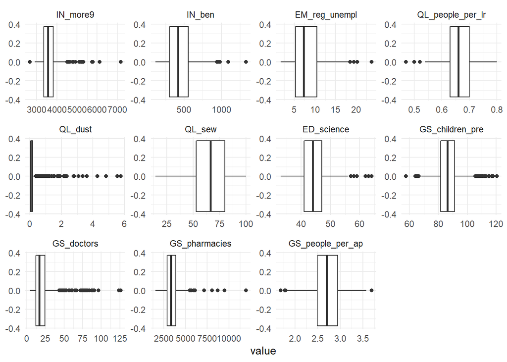

```r
indicValues <- melt(data = subset(dataAll, select= c("Kod", names(indicators))), id.vars = "Kod")
ggplot(data = indicValues) +
  geom_boxplot(mapping = aes(x = value)) +
  facet_wrap(~variable, scales = "free") +
  theme_minimal()
```

To perform clustering analysis first we need to clean up dataset. First, I will change all the values of *GS_children_pre* that are over 100% to 100%.

```r
dataAll[GS_children_pre > 100, GS_children_pre  := 100]
```

Next step is to replace missing values for *QL_dust*

```r
dataAll[is.na(QL_dust), QL_dust  := 0]
```

Final step is to standardize the variables.

```r
dataAllZ <- as.data.frame(lapply(subset(dataAll, select= finalVar), scale))
```

# Clustering - choosing the optimal number of clusters

In the first step, we will find the optimal number of clusters. We will do this by using the silhouette coefficient for various clustering methods:

- k-means
- PAM
- CLARA
- hierarchical

Each of the methods will be applied for the number of clusters from 2 to 10. The number of clusters with the highest silhouette value will be chosen as the optimal.

## K-means

To find optimal number of cluster for k-means method we will use ClusterR::Optimal_Clusters_KMeans function. This allows us to plot the results.

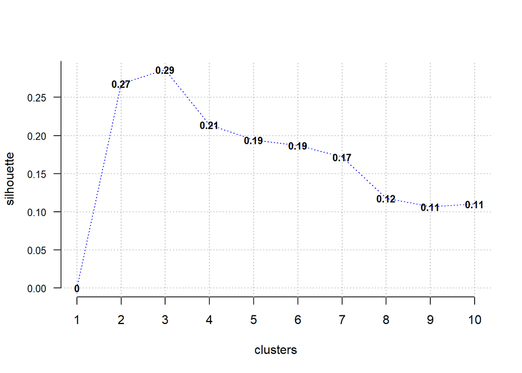

```r
resKMeans <- Optimal_Clusters_KMeans(data = dataAllZ, max_clusters = maxC, plot_clusters = TRUE, criterion = "silhouette")
```

Using k-means method and silhouette value we establish that optimal number of clusters is equal to 3.

## PAM

To find optimal number of clusters with PAM (partition around medoids) algorithm we need to use factoextra::eclust function (since CLusterR::Optimal_Clusters_Medoids function requires response from the user).

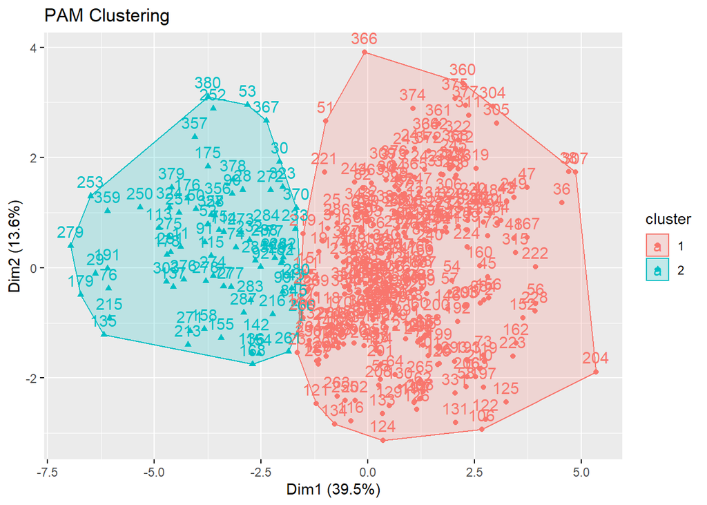

```
## Medoids:
##       ID       xaxis      yaxis  ED_science EM_reg_unempl GS_children_pre
## [1,]  98  0.39715469 -0.3406773 -0.08587943    -0.3498208      -0.3557464
## [2,] 274 -0.08404431 -0.7596429  1.25002285    -0.9720884       1.5896162
##      GS_doctors GS_people_per_ap GS_pharmacies     IN_ben   IN_more9    QL_dust
## [1,] -0.6061297        0.1977183   -0.03976526  0.2519467 -0.7983213 -0.2290957
## [2,]  1.4041438       -1.6226835   -1.13745701 -0.8040265  0.1662387  0.5484413
##      QL_people_per_lr      QL_sew
## [1,]        0.1526041 -0.01586854
## [2,]       -0.8611991  1.20386908
## Clustering vector:
##   [1] 1 1 1 1 1 1 1 1 1 1 2 1 1 1 1 1 1 1 1 1 1 1 1 1 1 1 2 2 2 2 1 1 1 1 1 1 1
##  [38] 1 1 1 1 1 1 1 1 1 1 1 1 2 1 2 2 1 1 1 1 1 1 1 1 1 1 1 1 1 1 1 1 1 1 1 1 2
##  [75] 2 2 2 1 1 1 1 1 1 1 1 1 1 1 1 2 2 2 1 1 1 1 1 1 2 1 1 1 1 1 1 1 1 1 1 1 1
## [112] 1 2 2 2 1 1 1 1 1 1 1 1 1 1 1 1 1 1 1 1 1 1 1 2 2 2 1 1 1 1 2 1 1 2 1 1 1
## [149] 1 1 1 1 1 2 2 1 1 2 1 1 1 1 1 1 1 1 1 2 1 1 1 1 1 1 2 2 2 2 2 1 1 2 1 1 1
## [186] 1 1 1 1 1 2 1 1 1 1 1 1 1 1 1 1 1 1 1 1 1 1 1 1 1 1 1 2 2 2 2 1 1 1 1 1 1
## [223] 1 1 1 1 1 1 1 1 2 2 2 1 1 1 1 1 1 1 1 1 1 1 1 1 1 1 1 2 2 2 2 1 1 1 1 1 1
## [260] 1 2 1 1 1 1 2 1 1 1 1 2 2 2 2 2 2 2 2 2 2 2 2 2 2 2 1 2 2 1 1 1 1 1 1 1 1
## [297] 1 1 1 1 1 1 2 1 1 1 1 1 1 1 1 1 1 1 1 1 1 1 1 1 1 1 2 2 1 1 1 1 1 1 1 1 1
## [334] 1 1 1 1 1 1 1 1 1 1 1 2 1 1 1 1 1 1 1 1 1 1 2 2 2 2 1 1 1 1 1 1 1 2 1 1 2
## [371] 1 1 1 1 1 1 1 2 2 2
## Objective function:
##    build     swap
## 3.132166 3.132166
##
## Available components:
##  [1] "medoids"    "id.med"     "clustering" "objective"  "isolation"
##  [6] "clusinfo"   "silinfo"    "diss"       "call"       "data"
## [11] "clust_plot" "nbclust"
```

```r
pamRes <- unlist(
    lapply(
        X = vecC,
        FUN = function(i)
        {
            clara_flex <- eclust(x = dataAllZ, FUNcluster = "pam", k = i, graph = F)
            clara_flex$silinfo$avg.width

        }
    )
)
optPAM <- vecC[which(pamRes == max(pamRes))]
eclust(x = dataAllZ, FUNcluster = "pam", k=optPAM)
```

Also PAM algorithm indicates that the optimal number of clusters is equal to 2.

## CLARA

Using CLARA (Clustering Large Applications) for dataset containing 380 observations and 13 variables is kind of overkill, but we will do it just to see if it gives similar results to PAM algorithm. We will also use factoextra::eclust function.

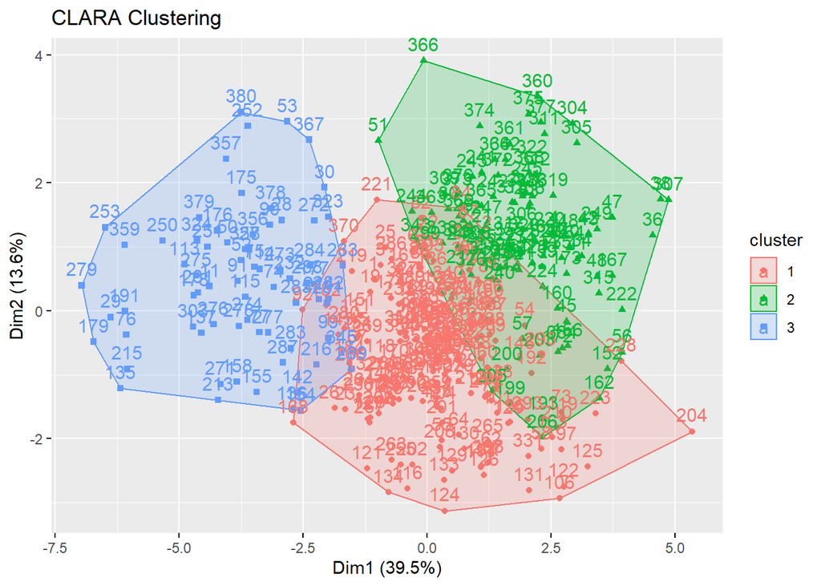

```
## Call:     fun_clust(x = x, k = k)
## Medoids:
##            xaxis      yaxis ED_science EM_reg_unempl GS_children_pre
## [1,]  0.28706427 -0.7405421  0.1049638    -0.1683261      -0.4828943
## [2,]  0.28909431  1.0157242 -1.0400953     1.4132707      -0.8261936
## [3,] -0.08404431 -0.7596429  1.2500228    -0.9720884       1.5896162
##       GS_doctors GS_people_per_ap GS_pharmacies       IN_ben   IN_more9
## [1,]  0.02754351       -0.2160094     0.1156937 -0.003881833 -0.1391159
## [2,] -0.33845737        0.3080457    -0.3800687  0.594865902 -0.7195026
## [3,]  1.40414383       -1.6226835    -1.1374570 -0.804026535  0.1662387
##         QL_dust QL_people_per_lr      QL_sew
## [1,] -0.2985187       -0.2529172 -0.67589972
## [2,] -0.3401724        0.7608860  0.04749445
## [3,]  0.5484413       -0.8611991  1.20386908
## Objective function:   2.911115
## Clustering vector:    int [1:380] 1 1 1 2 1 1 1 1 1 1 3 1 1 1 1 1 1 1 ...
## Cluster sizes:            201 108 71
## Best sample:
##  [1]   5  34  39  50  51  57  65  68  72  74  84 122 126 137 138 153 166 183 189
## [20] 198 201 209 231 233 241 244 256 274 275 280 285 288 289 302 305 306 312 320
## [39] 321 323 331 335 353 363 371 372
##
## Available components:
##  [1] "sample"     "medoids"    "i.med"      "clustering" "objective"
##  [6] "clusinfo"   "diss"       "call"       "silinfo"    "data"
## [11] "clust_plot" "nbclust"
```

```r
ccRes <- unlist(
    lapply(
        X = vecC,
        FUN = function(i)
        {
            clara_flex <- eclust(x = dataAllZ, FUNcluster = "clara", k = i, graph = F)
            clara_flex$silinfo$avg.width

        }
    )
)
optClara <- vecC[which(ccRes == max(ccRes))]
eclust(x = dataAllZ, FUNcluster = "clara", k=optClara)
```

CLARA algorithm suggests 3 as the optimal number of clusters.

## Hierarchical Clustering

We will try hierarchical clustering for the last try (using factoextra::fviz_nbclust).

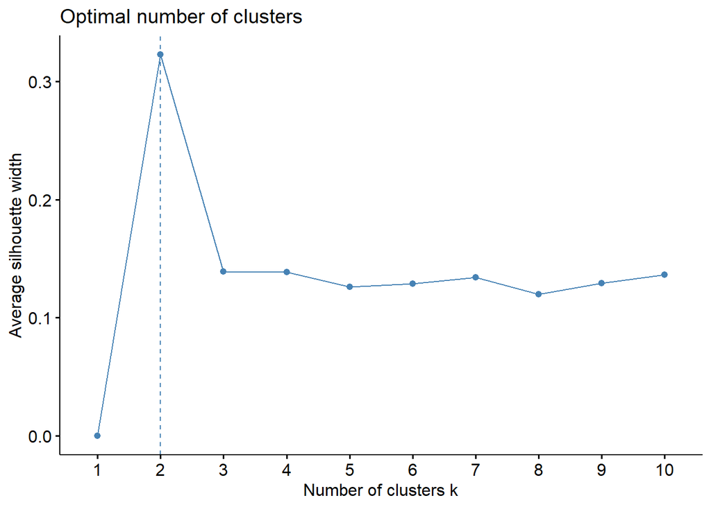

```r
hcRes <- fviz_nbclust(x = dataAllZ, FUN = hcut, method = "silhouette", k.max = maxC)
optHier <- hcRes$data[order(-hcRes$data$y), ]$clusters[1]
hcRes
```

Hierarchical Clustering algorithm also suggests 2 clusters.

## Summ up

2 out of 4 methods suggests 3 clusters and this is the number we will choose for further analysis.

# Quality of clusterization

In this section we will try to assess the quality of clusterization. We will use several measures to test whether this analysis provides useful insight.

## Shadow statistics

Shadow statistics is based on the relation between observations and cluster centroids. Its value ranges from 0 to 1:

- values closer to 0 mean that points are closer to centroids of clusters which means that our clustering result is of high quality.
- values closert to 1 means that observations are to some extent equidistant to all cluster centroids which means that clustering result is poor quailty

To calculate shadow statistics we will use flexclust::cclust function.

```r
optKmeans <- which(resKMeans == max(resKMeans))
shadowStat <- cclust(x = dataAllZ, optKmeans, dist="euclidean") #:: for k-means
shadow(shadowStat)
```

```
##         1         2         3
## 0.8057237 0.7815905 0.8248661
```

Looking at those value this clustering is of poor quality. One can look into graph for individual clusters.

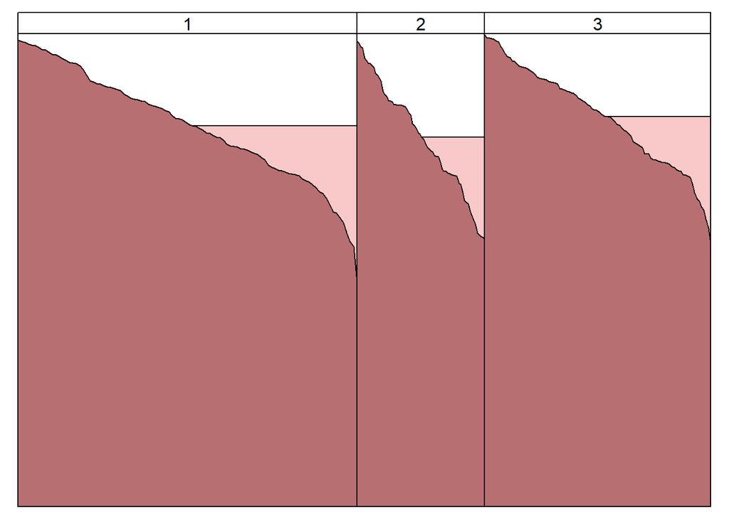

```r
plot(shadow(shadowStat))
```

## Hopkins statistic

Hopkins statistics measures clusterability of data:

- if values are uniformly distributed the statistic will be close to 0
- if values is randomly distirbuted, the statistic will be around 0.5
- if values are clustered, the statistic will be close to 1

To calculate Hopkins statistics we will use clustertend::hopkins function. Because it is a sample-base statistic we will run it 10 times to see if the results are stable.

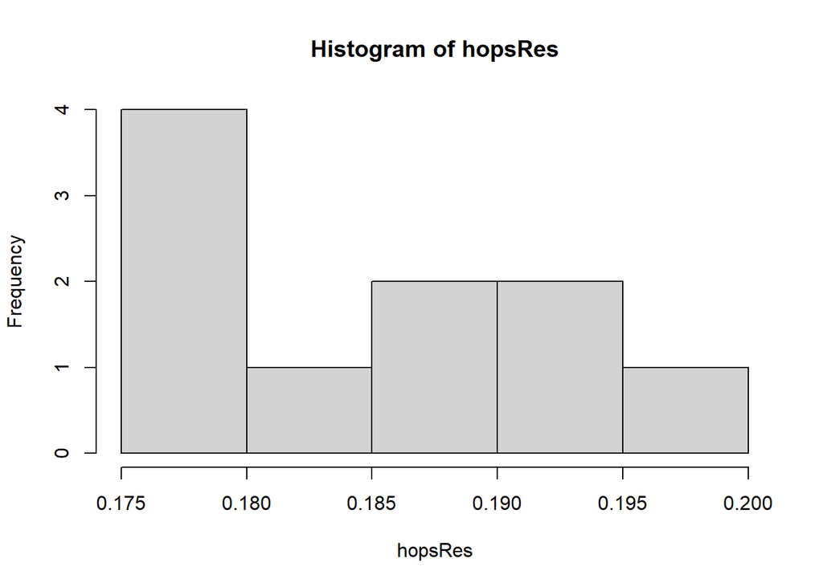

```r
hopsRes <- unlist(lapply(X = 1:10, FUN = function(i) hopkins(X = dataAllZ)[[1]]))
hist(hopsRes)
```

## Rand index

```r
set.per1<-dataAllZ[,1:floor(ncol(dataAllZ) / 2)]
set.per2<-dataAllZ[,floor(ncol(dataAllZ) / 2):ncol(dataAllZ)]
d1<-cclust(set.per1, optKmeans, dist="euclidean")
d2<-cclust(set.per2, optKmeans, dist="euclidean")
comPart(d1, d2)
```

```
##       ARI        RI         J        FM
## 0.2184898 0.5941397 0.4303146 0.6133400
```

Rand index of 0.59 tells us that sometimes clustering is stable (1 means that partitioning data set do not affect result of clustering at all).

## Calinski-Harabasz

Calinski-Harabasz index is used for comparing solutions for alternative number of clusters. For comparison we will choose the number of clusters with second largest value of silhouette index.

```r
secOptKMeans <- which(resKMeans == max(setdiff(resKMeans, max(resKMeans))))
km1 <- kmeans(x = dataAllZ, centers = optKmeans)
km2 <- kmeans(x = dataAllZ, centers = secOptKMeans)

round(calinhara(dataAllZ, km1$cluster),digits=2);round(calinhara(dataAllZ, km2$cluster),digits=2)
```

```
## [1] 112.46
```

```
## [1] 134.73
```

Since higher value of Calinski-Harabasz index means better result therefore the second best number of clusters, according to the index, would provide better results for analysis.

## Duda-Hart

Duda-Hart is statistical test with corresponding hypothesis:

- H0: homogeneity of cluster (data within cluster as similar)
- H1: heterogeneity of cluster (one can easily split the cluster)

```r
km3 <- kmeans(x = dataAllZ, centers = optKmeans)
dudahart2(x = dataAllZ, clustering = km3$cluster)$p.value
```

```
## [1] 0
```

Since p.value is < 5% we reject H0 and accept H1: we can split the clusters further.

## Summ up

Based on the tests and statistics this clusterization is not high quality.

# Analysis of final clusters

## Basic analysis

Based on the results presented earlier we assign each district to one of the clusters.

```r
finalKmeans <- kmeans(dataAllZ, optKmeans)
dataAll$kmeans <- finalKmeans$cluster
dataAllM <- melt(dataAll, id.vars = c("Kod", "kmeans"))
dataAllM <- dataAllM[variable %in% names(indicators),.(mean(value)), by = .(kmeans, variable)]
dataAllD <- dcast(dataAllM, formula = kmeans ~ variable, value.var = "V1")
dataAllD
```

```
##    kmeans ED_science EM_reg_unempl GS_children_pre GS_doctors GS_people_per_ap
## 1:      1   44.44271      6.860938        87.15677   17.45313         2.751458
## 2:      2   41.12712     11.829661        79.14068   13.07034         2.882203
## 3:      3   50.07143      5.478571        97.63571   52.75857         2.188286
##    GS_pharmacies   IN_ben IN_more9    QL_dust QL_people_per_lr   QL_sew
## 1:      3449.443 371.8385 3612.866 0.08260417        0.6565625 62.22240
## 2:      4087.500 630.1441 3410.994 0.02677966        0.7006780 56.56186
## 3:      2734.900 315.7286 4215.259 1.22114286        0.6142857 90.10286
```

Cluster 3 is least deprived:

- higher score from science test
- lower unemployment rate
- higher percentage of children covered by pre-school care
- best access to pharmacies and doctors
- lowest rate of beneficiaries of environmental social assistance
- smallest number of people per room/apartment
- highest percentage of population using sewage system

Higher pollution in this cluster might be associated with location of large group of districts from this cluster (Silesia).

If we look at the map we can see that this cluster consists mainly of two types of districts:

- cities with district rights
- districts surrounding Warsaw or located near Silesia

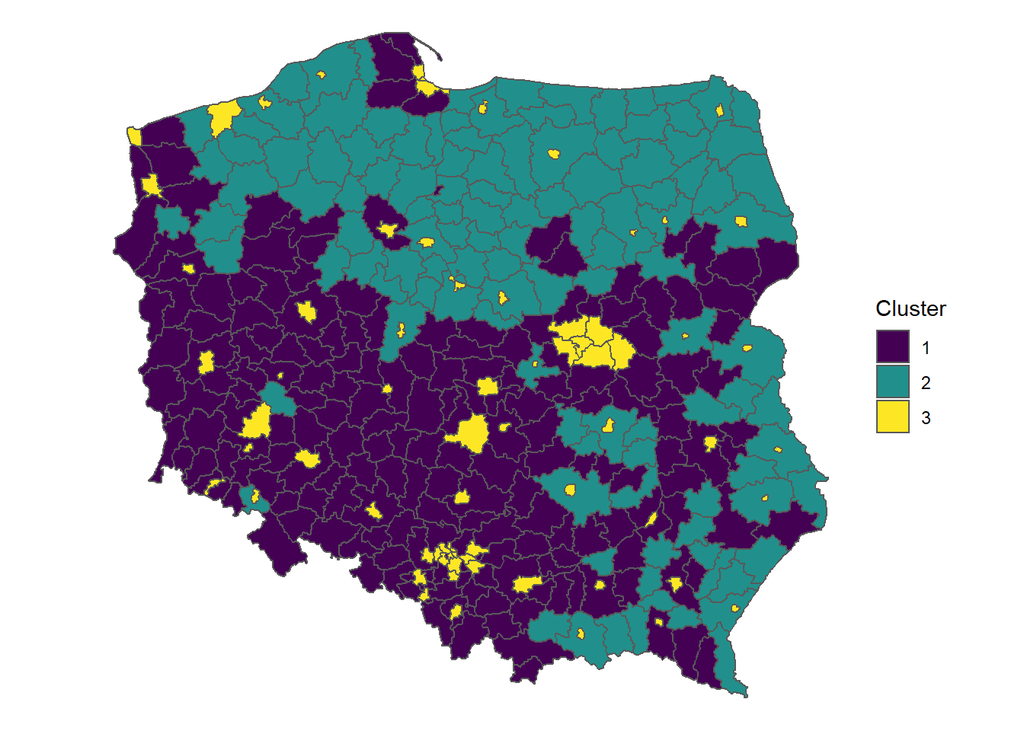

```r
res <- as.data.frame(dataAll[,.(JPT_KOD_JE = Kod, kmeans)])
resMap <- merge(shapes_powiaty, res, by = "JPT_KOD_JE")
resMap <- sf::st_as_sf(resMap)
ggplot() +
    geom_sf(data = resMap, mapping = aes(fill = as.factor(kmeans))) +
    scale_fill_viridis_d() +
    theme_void() +
    labs(fill = "Cluster")
```

Cluster 2 is most deprived cluster:

- lowest score from science test
- highest unemployment
- lowest percentage of children covered by pre-school care
- worst access to doctors or pharmacies
- most crowded apartments
- highest rate of beneficiaries of environmental social assistance
- lowest percentage of population using sewage system

If we look at the map we can see that this cluster consists mainly of two types of districts:

- those located in northern Poland (with exception of surroundings of Trójmiasto)
- those located in eastern Poland

## Main questions

To remind, we started with two main questions:

1. Is it true that people in big cities have better lives, better opportunities than people in so called province?
2. Is it true that after so many years after Poland regained independence, the partitions are still visible (*pl - czy widać zabory*)?

### Is it true that people in big cities have better lives, better opportunities than people in so called province?

```r
resMap2 <- as.data.table(resMap)
resMap2[, cityWithDistrictRights := substr(JPT_KOD_JE, 3, 3) %in% c("6", "7")]
resMap3 <- resMap2[,.(.N, whatDis = paste0(JPT_NAZWA_, collapse = ", ")), by = .(kmeans, cityWithDistrictRights)]
dcast(data = resMap3, formula = kmeans ~ cityWithDistrictRights, value.var = "N", fill = 0)
```

```
##    kmeans FALSE TRUE
## 1:      1   188    4
## 2:      2   118    0
## 3:      3     8   62
```

Only 4 cities with district rights is in a different cluster than the other cities with district rights (powiat Grudziądz, powiat Mysłowice, powiat Świętochłowice, powiat Żory). And the cluster with almost all cities of that kind is less deprived. Which might lead to the conclusion that people in big cities have better lives/opportunities than people in so called province.

### Is it true that after so many years after Poland regained independence, the partitions are still visible (pl - czy widać zabory)?

Lets look at simple map that shows approximate division of Poland based on the borders of the partitions.

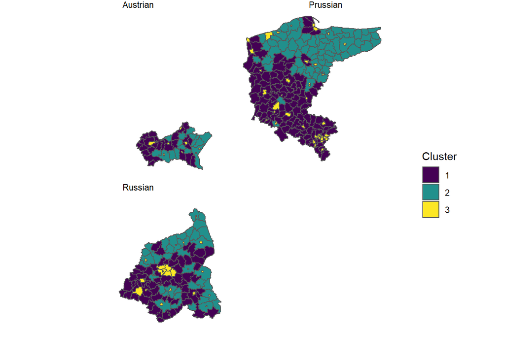

```r
ggplot() +
    geom_sf(data = res2, mapping = aes(fill = as.factor(kmeans))) +
    scale_fill_viridis_d() +
    theme_void() +
    labs(fill = "Cluster") + facet_wrap(~f, nrow = 2)
```

The above analysis does not give grounds to conclude that the deprivation of regions is related to the partitions.

# Sources

Smętkowski, Maciej, Grzegorz Gorzelak, and Adam Płoszaj. “Powiaty zagrożone deprywacją: stan, trendy i prognoza.” (2015).

Local Data Bank, https://bdl.stat.gov.pl/bdl/start

Mapa Egzaminów, https://mapa.wyniki.edu.pl/MapaEgzaminow/